# Support Vector Machines (SVM)

Introductory analysis via NNET

Georgios P. Karagiannis @ MATH3431 Machine Learning and Neural Networks III

[Back to README](https://github.com/georgios-stats/Machine_Learning_and_Neural_Networks_III_Epiphany_2023/tree/main/Computer_practical#aim)

```r
rm(list=ls())
```

*Aim*

Students will become able to:

- practice in R,
- implement Support Vector Machine (classifiers) with R package **e1071** in R.

*Reading material*

- Lecture notes:
  - [Handout 6: Support Vector Machines](https://github.com/georgios-stats/Machine_Learning_and_Neural_Networks_III_Epiphany_2023/blob/main/Lecture_handouts/06.Support_Vector_Machines.pdf)
- References for the R package (optional supplamentary material for your information)
  - [e1071 in R Cran](https://cran.r-project.org/web/packages/e1071/)
  - [e1071 Vignettes](https://cran.r-project.org/web/packages/e1071/vignettes/svmdoc.pdf)
  - [e1071 Vignettes](https://cran.r-project.org/web/packages/e1071/vignettes/svminternals.pdf)
- Reference for *R*:
  - [Cheat sheet with basic commands](https://iqss.github.io/dss-workshops/R/Rintro/base-r-cheat-sheet.pdf)
- Reference of *rmarkdown* (optional given as supplementary material):
  - [R Markdown cheatsheet](https://www.rstudio.com/wp-content/uploads/2015/02/rmarkdown-cheatsheet.pdf)
  - [R Markdown Reference Guide](https://www.rstudio.com/wp-content/uploads/2015/03/rmarkdown-reference.pdf)
  - [knitr options](https://yihui.org/knitr/options/)
- Reference for *Latex* (optional given as supplementary material):
  - [Latex Cheat Sheet](https://wch.github.io/latexsheet/latexsheet-a4.pdf)

*New software*

- R package **e1071** functions:
  - **svm{e1071}** : Used to train SVM.
  - **predict{e1071}**: Using this method, we obtain predictions from the model, as well as decision values from the binary classifiers.
  - **plot{e1071}** : Visualizing data, support vectors and decision boundaries, if provided.
  - **tune{e1071}** : Hyperparameter tuning uses tune() to perform a grid search over specified parameter ranges.

```r
# Load R package for printing
library(knitr)
```

```r
# Set a seed of the randon number generator
set.seed(2023)
```

# 1 Familiarity with analysis with Support Vector Machine classifiers with e1071 R package

We will use the R package e1071 It is available from

- https://cran.r-project.org/web/packages/e1071/

The reference manual is available from

- https://cran.r-project.org/web/packages/e1071/e1071.pdf

Details

- **svm{e1071}** : Used to train SVM.
- **predict{e1071}**: Using this method, we obtain predictions from the model, as well as decision values from the binary classifiers.
- **plot{e1071}** : Visualizing data, support vectors and decision boundaries, if provided.
- **tune{e1071}** : Hyperparameter tuning uses tune() to perform a grid search over specified parameter ranges.

## 1.1 Task: Install e1071

```r
## build version (recommended)
#install.packages("e1071")
## linux build
#install.packages("https://cran.r-project.org/src/contrib/e1071_1.7-13.tar.gz", repos = NULL, type = "source")
## windows build
#install.packages("https://cran.r-project.org/bin/windows/contrib/4.2/e1071_1.7-13.zip", repos = NULL, type = "source")
```

```r
library(e1071)
```

## 1.3 Task: About e1071 commands

Check out R package **e1071** commands from the reference manual is available from

- https://cran.r-project.org/web/packages/e1071/e1071.pdf

in particular: **svm{e1071}**, **predict{e1071}**, **plot{e1071}**, **tune{e1071}**

- Library **e1071** contains implementations for a number of statistical learning methods.
- R function **svm()** can be used to fit a support vector classifier when the argument **kernel = “linear”** is used.
- **cost** argument allows us to specify the cost of a violation to the margin.
  - It is the cost of constraints violation (default: 1)—it is the ‘C’-constant of the regularization term in the Lagrange formulation; as follows.
    $$\begin{align}
    \left(w^{*},b^{*},\xi^{*}\right) & =\underset{\left(w,b,\xi\right)}{\arg\min}\left(\frac{1}{2} \left\Vert w\right\Vert _{2}^{2}+C\frac{1}{m}\sum_{i=1}^{m}\xi_{i}\right)\label{eq:-2-1}\\
    \text{subject to: , ,}\, & y_{i}\left(\langle w^{*},x_{i}\rangle+b^{*}\right)\ge1-\xi_{i},\,\,\forall i=1,...,m\label{eq:-3-1}\\
    & \xi_{i}\ge0, , ,\forall i=1,...,m\label{eq:-5}
    \end{align}$$
    Note that we can consider that $C=\frac{1}{2\lambda}$ in Algorithm Soft-SVM in Handout 6: Support Vector Machines.
  - When the cost argument is small, then the margins will be wide and many support vectors will be on the margin or will violate the margin. When the cost argument is large, then the margins will be narrow and there will be few support vectors on the margin or violating the margin.
  - It is the cost of constraints violation (default: 1)—it is the ‘C’-constant of the regularization term in the Lagrange formulation.

Below we demonstrate the use of this function on a two-dimensional example so that we can plot the resulting decision boundary.

# 2 Support Vector Machine (Binary classification)

Consider the training data set of the examples given below:

Is it separable?

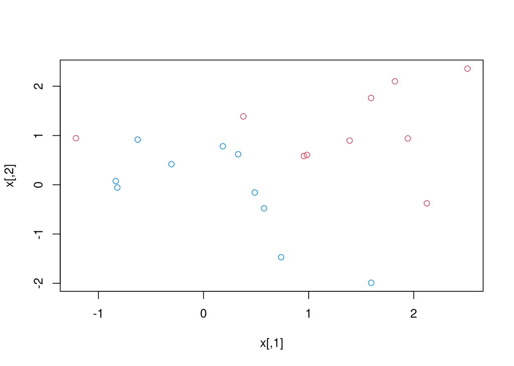

```r
set.seed(1)
x <- matrix(rnorm(20 * 2), ncol = 2)
y <- c(rep(-1, 10), rep(1, 10))
x[y == 1, ] <- x[y == 1, ] + 1
plot(x, col = (3 - y))
```

Well the answer is No.

We must encode the response as a factor variable:

```r
dat <- data.frame(x = x, y = as.factor(y))
```

## 2.1 Task: Fit the SVM classifier

To fit the SVM classifier use the R function **svm{e1071}** (check ?svm).

Use the arguments:

- **cost = 10**
- **kernel = “linear”** to set a linear link function (we will call it kernel in the next lectures).
- **scale = FALSE** to impose svm not to scale each feature to have mean zero or standard deviation one.

Save the output to object **svmfit**

```r
#
#
#
```

## 2.2 Task: Plot the support vector classifier obtained

Plot the support vector classifier obtained by using the R function **plot**.

Use it as **plot( my_obj , my_data )**

```r
#
#
#
```

The decision boundary between the two classes is linear (because of kernel = “linear”)

### 2.2.1 Task: Get the support vectors locations

Print **svmfit$index**

```r
#
#
#
```

## 2.3 Print the summary

Use the R function **summary()** to print the basic information summary of the training.

```r
#
#
#
```

## 2.4 Task: Play with cost argument

Re-fit the SVM classifier with the R function *svm{e1071}* with argument **cost=0.1** (aka smaller than before).

Save the output returned by R function **svm** as **svmfit**.

Plot it, and print the support vectors saved in **svmfit$index**.

What do you observe?

```r
#
#
#
```

## 2.5 Task: Perform cross validation for tuning and model comparison

The e1071 library includes a built-in function, **tune{o1071}**.

Use the R function **tune{e1071}**, to perform cross-validation. Check **?tune**.

By default, tune() performs ten-fold cross-validation on a set of models of interest.

In order to use this function, we pass in relevant information about the set of models that are under consideration.

## 2.6 Choose a preferable value for the argument **cost**.

Check via cross validation which is the best value for cost argument among in particular the values 0.001, 0.01, 0.1, 1, 5, 10, and 100.

First we compare different parametrizations of svm clascifier each of them with different **cost** argument; in particular the values 0.001, 0.01, 0.1, 1, 5, 10, and 100.

Use the arguments:

- **METHOD=svm** for using the svm methodology
- **kernel = “linear”** for the link “y~1 +x1 +x2” to be linear wrt the regressors.
- **ranges = list(cost = c(0.001, 0.01, 0.1, 1, 5, 10, 100))** to test over a range of cost values

Save the output in the object **tune.out** .

```r
set.seed(1) # keep me for consistency reasons
#
tune.out <- tune(METHOD=svm,
                 y ~ ., data = dat,
                 kernel = "linear",
                 ranges = list(cost = c(0.001, 0.01, 0.1, 1, 5, 10, 100))
                 )
```

Use function **summary** to print the results.

Which value is the preferable one?

```r
#
#
#
```

## 2.7 Print the results from the Cross Validation

The fit of the best model is saved in the value **tune.out$best.model** of the output of R function **tune()**.

Save it in the object **bestmod<-tune.out$best.model**.

Print the summary of **bestmod**.

```r
#
#
#
```

## 2.8 Task: Predictions

The **predict()** function can be used to predict the class label on a set of test observations, at any given value of the cost parameter.

Consider the following new data set.

```r
xtest <- matrix(rnorm(20 * 2), ncol = 2)
ytest <- sample(c(-1, 1), 20, rep = TRUE)
xtest[ytest == 1, ] <- xtest[ytest == 1, ] + 1
testdat <- data.frame(x = xtest, y = as.factor(ytest))
```

1. Predict the class labels of these test observations.

   Use the best model obtained through cross-validation, aka **bestmod** in order to make predictions.

```r
#
#
#
```

2. Compute the SVM confusion matrix (miss-classification table)

   Use the R function **table()**.

How many correct classifications?

```r
#
#
#
```

3. Compute how many correct classifications I can get with **cost = 0.01**.

   Use R function **svm** ; then **predict** ; then **table**.

```r
#
#
#
```

## 2.9 Task: Linearly separable cases.

Consider the case that the training data set is linearly separable. Use the new provided data

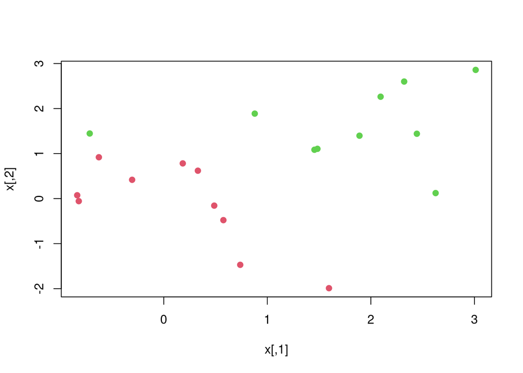

```r
x[y == 1, ] <- x[y == 1, ] + 0.5
plot(x, col = (y + 5) / 2, pch = 19)
```

```r
dat <- data.frame(x = x, y = as.factor(y))
```

Fit the support vector classifier.

Plot the resulting hyperplane, using a very large value of cost so that no observations are misclassified; eg **cost=1e5**.

```r
#
#
#
```

It seems likely that this model will perform poorly on test data.

We now try to fit the svm with a smaller value of cost **cost=1**.

```r
#
#
#
```

# 3 Support Vector Machine with non-linear kernels.

In order to fit an SVM using a non-linear kernel, we once again use the **svm()** function. However, now we use a different value of the parameter `kernel`.

To fit an SVM with a polynomial kernel we use **kernel = “polynomial”**.

In Particular the polynomial kernel is:

$$(\gamma u^\top v+c_0)^d$$

So we can use the arguments

- **degree** to specify a degree $d$ for the polynomial kernel.
- **gamma**, for $\gamma$
- **coef0**, for $c_0$

We use the following non-separable data.

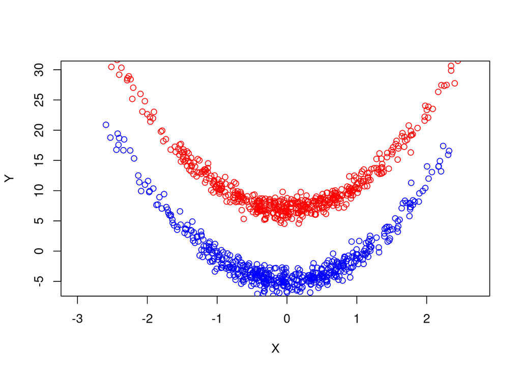

```
integer(0)
```

```r
set.seed(1)
N = 1000
xx = rnorm(N)
yy = 4 * xx^2 + 1 + rnorm(N)
class = sample(N, N/2)
yy[class] = yy[class] + 6
yy[-class] = yy[-class] - 6
x <- cbind(xx,yy)
plot(x[class,1], x[class,2], col = "red", xlab = "X", ylab = "Y", ylim = c(-6, 30)) +
points(x[-class,1], x[-class,2], col = "blue")
```

```r
#
y = rep(-1, N)
y[class] = 1
data = data.frame(x = x, y = as.factor(y))
train = sample(N, N/2)
data_train = data[train, ]
data_eval = data[-train, ]
```

Perhaps using a linear prediction rule (linear wrt the features) is not the best way to go.

See below.

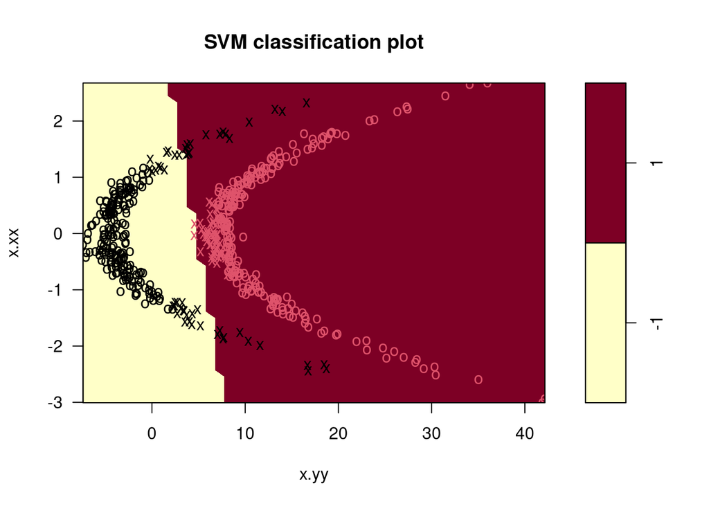

```r
svm_linear = svm(y ~ ., data = data_train, kernel = "linear", cost = 1)
plot(svm_linear, data_train)
```

## 3.1 Fit with polynomial kernel.

Fit the SVM classifier by using a polynomial kernel of degree $d=2$.

In Particular the polynomial kernel is:

$$(\gamma u^\top v+c_0)^d$$

Use arguments

- **kernel = “polynomial”**, for the polynomial
- **degree=2**, for $d$
- **gamma=2**, for $\gamma$
- **coef0=0**, for $c_0$
- **cost = 1**

```r
#
#
#
```

## 3.2 Cross validation

Choose appropriate values for the parameters of the polynomial kernel in the following ranges

- **cost = c(0.01, 0.05, 0.1)**
- **gamma = c(0.5,1,2.0)**
- **coef0 = c(0,1,2)**
- **degree = c(1,2,3)**

Use the function **tune**.

Print the results with function **summary**.

Which parametrization is preferable?

```r
#
#
#
```